# 06 — Optimización: Features Dinámicas de Eventos Urbanos

Los modelos de los cuadernos 04 y 05 tienen importancia SHAP de eventos < 0.001 porque las variables de eventos son conteos globales diarios sin localización espacial.

Este cuaderno implementa tres mejoras:

1. **Features de partido por estadio**: Camp Nou y Estadio Olímpic tratados por separado, dado que difieren radicalmente en proximidad a la red viaria (180m vs 1.864km).
2. **Ventanas temporales horarias**: aprovechando que conocemos la hora de inicio de cada partido y concierto.
3. **Features de conciertos**: Palau Sant Jordi (245 conciertos) y Estadi Olímpic (15 conciertos grandes) como fuente complementaria de eventos de alta afluencia.

## 1. Justificación

### 1.1 Limitaciones del modelo actual

```python
import pandas as pd, numpy as np
import matplotlib.pyplot as plt, matplotlib
matplotlib.rcParams['figure.dpi'] = 100
import warnings; warnings.filterwarnings('ignore')
from numpy import radians, sin, cos, sqrt, arcsin

DATA_DIR = '../dataset'

def haversine_km(lat1, lon1, lat2, lon2):
    R = 6371.0
    dlat = radians(lat2 - lat1); dlon = radians(lon2 - lon1)
    a = sin(dlat/2)**2 + cos(radians(lat1))*cos(radians(lat2))*sin(dlon/2)**2
    return 2*R*arcsin(sqrt(a))

# Resumen modelos anteriores
print("Importancia SHAP de features de eventos en modelos anteriores:")
print("  modelo 04 — n_eventos_agenda: SHAP ≈ 0.0001 (rank 77/78)")
print("  modelo 05 — hay_festival:     SHAP ≈ 0.0009 (rank ~70/98)")
print()
print("Causa: features globales de ciudad sin dimensión espacial ni horaria.")
print("Solución: features por recinto × hora, separando estadios por distancia.")
```

```
Importancia SHAP de features de eventos en modelos anteriores:
  modelo 04 — n_eventos_agenda: SHAP ≈ 0.0001 (rank 77/78)
  modelo 05 — hay_festival:     SHAP ≈ 0.0009 (rank ~70/98)

Causa: features globales de ciudad sin dimensión espacial ni horaria.
Solución: features por recinto × hora, separando estadios por distancia.
```

### 1.2 Proximidad de los recintos a la red viaria

El primer paso es cuantificar la distancia de cada recinto a los tramos viales. Esta distancia determina si el efecto del evento puede ser detectable en los datos.

```python
# Cargar tramos
df_base = pd.read_parquet(f'{DATA_DIR}/integrated/dataset_features_mejora.parquet',
                          columns=['idTram','lat_centre','lon_centre'])
trams = df_base[['idTram','lat_centre','lon_centre']].drop_duplicates().set_index('idTram')

RECINTOS = {
    'Camp Nou':                         (41.380896, 2.122820, 99000),
    'Estadio Olímpic Lluís Companys':   (41.364919, 2.154234, 55000),
    'Palau Sant Jordi':                 (41.364767, 2.151485, 17000),
}

print(f"{'Recinto':<32} {'Aforo':>7}  {'Dist.min':>9}  {'<1km':>5}  {'<2km':>5}  {'<3km':>5}")
print('-'*72)
for name, (lat, lon, cap) in RECINTOS.items():
    dists = haversine_km(lat, lon, trams['lat_centre'].values, trams['lon_centre'].values)
    print(f"{name:<32} {cap:>7,}  {dists.min()*1000:>7.0f}m  "
          f"{(dists<1).sum():>5}  {(dists<2).sum():>5}  {(dists<3).sum():>5}")
print()
print("→ Camp Nou es el único recinto adyacente a la red viaria (180m).")
print("→ Estadi Olímpic y Palau Sant Jordi están a >1.6km del tramo más cercano.")
```

```
Recinto                            Aforo   Dist.min   <1km   <2km   <3km
------------------------------------------------------------------------
Camp Nou                          99,000      180m     19     41     48
Estadio Olímpic Lluís Companys    55,000     1864m      0      2      8
Palau Sant Jordi                  17,000     1655m      0      2     10

→ Camp Nou es el único recinto adyacente a la red viaria (180m).
→ Estadi Olímpic y Palau Sant Jordi están a >1.6km del tramo más cercano.
```

### 1.3 Por qué analizar Camp Nou y Estadio Olímpic por separado

El FC Barcelona jugó en el **Camp Nou** hasta junio de 2023 (reforma), y desde agosto de 2023 en el **Estadio Olímpic**. Estos dos estadios tienen impactos radicalmente distintos sobre el tráfico viario:

| Aspecto | Camp Nou | Estadio Olímpic |
| --- | --- | --- |
| Distancia mínima a la red viaria | **180m** | 1.864km |
| Tramos a <2km | **41/56** | 2/56 |
| Asistencia media (partidos) | **66.866** | 42.484 |
| Partidos en el periodo | 48 (2021-jun23) | 35 (ago23-2024) |
| Impacto esperable en tráfico viario | **Alto** | Bajo-moderado |

Mezclar ambos estadios en una misma feature diluye la señal del Camp Nou (donde el efecto es mayor) con el ruido del Estadio Olímpic (donde es menor).

### 1.4 Por qué añadir datos de conciertos

Los conciertos aportan una señal complementaria a los partidos:

| Fuente | Eventos | Aforo medio | Frecuencia | Recinto |
| --- | --- | --- | --- | --- |
| Partidos FCB (Camp Nou) | 48 | 66.866 | Quincenal | 180m de la red viaria |
| Partidos FCB (Olímpic) | 35 | 42.484 | Quincenal | 1.864km |
| Conciertos Palau Sant Jordi | **245** | 11.286 | **Semanal** | 1.655km |
| Conciertos Estadi Olímpic | 15 | 99.742 | Puntual | 1.864km |

## 2. Exploración de los Datos de Eventos

```python
# Cargar datos de partidos
partidos = pd.read_csv(f'{DATA_DIR}/Partidos_FCB/partidos_fcb_casa.csv')
partidos['fecha_dt'] = pd.to_datetime(partidos['fecha'])
partidos['year'] = partidos['fecha_dt'].dt.year

# Cargar datos de conciertos
conciertos = pd.read_csv(f'{DATA_DIR}/Conciertos/conciertos_barcelona.csv')
conciertos['fecha_dt'] = pd.to_datetime(conciertos['fecha'])
conciertos['year'] = conciertos['fecha_dt'].dt.year

print("=== Partidos FCB en casa ===")
print(partidos.groupby(['estadio','year']).agg(
    n=('fecha','count'), esp_media=('espectadores','mean'), esp_max=('espectadores','max')
).round(0).to_string())

print()
print("=== Conciertos ===")
print(conciertos.groupby(['recinto','year']).agg(
    n=('fecha','count'), esp_media=('espectadores','mean')
).round(0).to_string())
```

```
=== Partidos FCB en casa ===
                                      n  esp_media  esp_max
estadio                        year
Camp Nou                       2021  13    46020.0    86422
                               2022  21    72231.0    92605
                               2023  13    82347.0    95745
                               2024   1    23932.0    23932
Estadio Olímpic Lluís Companys 2023  13    41027.0    50112
                               2024  22    43345.0    50312

=== Conciertos ===
                                     n  esp_media
recinto                       year
Estadi Olímpic Lluís Companys 2022   2    55000.0
                              2023   9   130106.0
                              2024   4    53796.0
Palau Sant Jordi              2021  18    11556.0
                              2022  65    11831.0
                              2023  82    11878.0
                              2024  80    10175.0
```

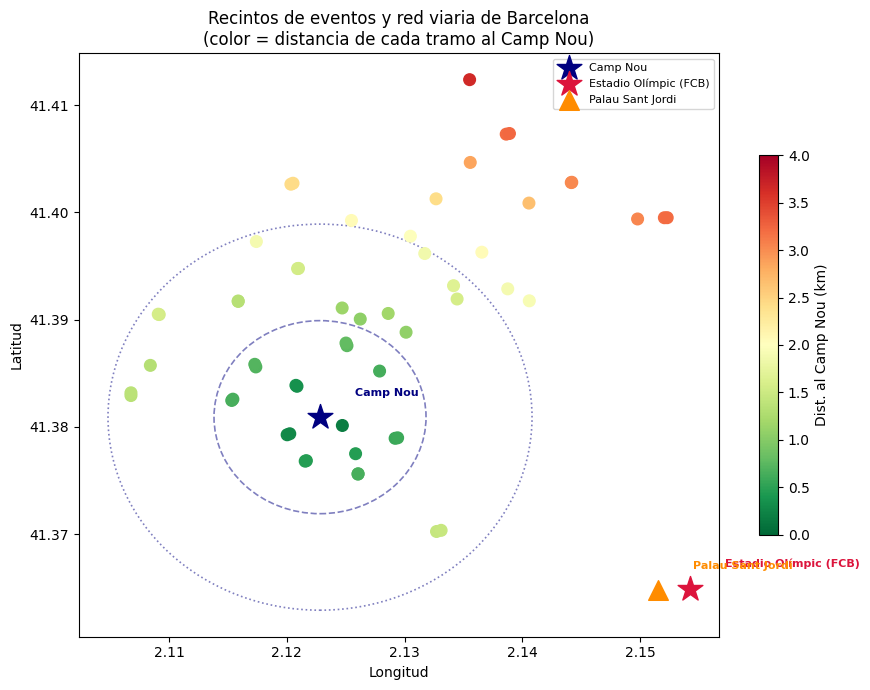

```python
# Mapa: todos los recintos y la red viaria
fig, ax = plt.subplots(figsize=(9,7))

# Tramos: colorear por distancia al Camp Nou
trams_r = trams.reset_index()
trams_r['d_campnou'] = haversine_km(41.380896, 2.122820,
                                    trams_r['lat_centre'], trams_r['lon_centre'])
sc = ax.scatter(trams_r['lon_centre'], trams_r['lat_centre'],
                c=trams_r['d_campnou'], cmap='RdYlGn_r', vmin=0, vmax=4,
                s=70, zorder=5)
plt.colorbar(sc, ax=ax, label='Dist. al Camp Nou (km)', shrink=0.65)

# Recintos
marcadores = [
    (41.380896, 2.122820, 'Camp Nou',             'navy',   '*', 350),
    (41.364919, 2.154234, 'Estadio Olímpic (FCB)','crimson','*', 350),
    (41.364767, 2.151485, 'Palau Sant Jordi',      'darkorange','^',200),
]
for lat, lon, lbl, c, marker, s in marcadores:
    ax.scatter(lon, lat, c=c, s=s, marker=marker, zorder=10, label=lbl)
    ax.annotate(lbl, xy=(lon, lat), xytext=(lon+0.003, lat+0.002),
                fontsize=8, color=c, fontweight='bold')

# Círculos 1km y 2km alrededor del Camp Nou
for r_deg, ls in [(0.009,'--'),(0.018,':')]:
    ax.add_patch(plt.Circle((2.122820, 41.380896), r_deg,
                            fill=False, linestyle=ls, alpha=0.5, linewidth=1.2, color='navy'))

ax.set_xlabel('Longitud'); ax.set_ylabel('Latitud')
ax.set_title('Recintos de eventos y red viaria de Barcelona\n'
             '(color = distancia de cada tramo al Camp Nou)')
ax.legend(fontsize=8, loc='upper right')
plt.tight_layout()
plt.show()
```

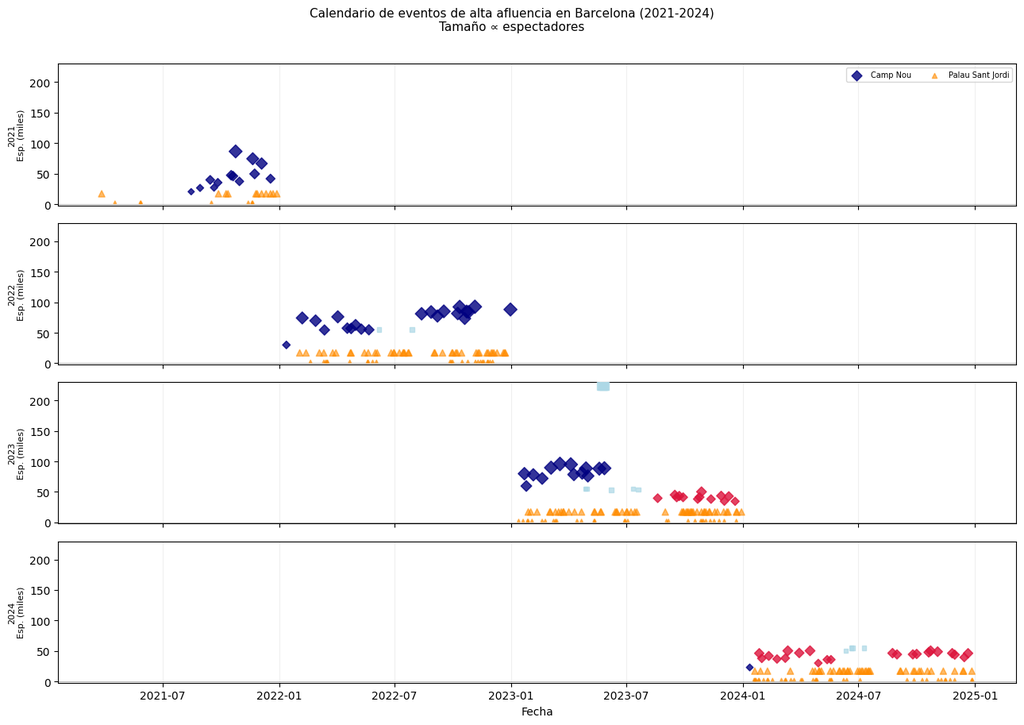

```
Fig. 2 — Calendario consolidado de eventos
```

```python
# Calendario consolidado de eventos 2021-2024
fig, axes = plt.subplots(4, 1, figsize=(13, 9), sharex=True)
years = [2021, 2022, 2023, 2024]
colores = {'Camp Nou':'navy', 'Estadio Olímpic Lluís Companys':'crimson',
           'Palau Sant Jordi':'darkorange', 'Estadi Olímpic Lluís Companys':'tomato'}

for ax, year in zip(axes, years):
    # Partidos
    for estadio, color in [('Camp Nou','navy'),('Estadio Olímpic Lluís Companys','crimson')]:
        sub = partidos[(partidos['year']==year) & (partidos['estadio']==estadio)]
        if len(sub):
            dts = pd.to_datetime(sub['fecha'])
            esps = sub['espectadores'] / 1000
            ax.scatter(dts, esps, c=color, s=esps*0.8, marker='D',
                       alpha=0.8, zorder=5, label=estadio if year==2021 else '')
    # Conciertos PSJ
    sub_psj = conciertos[(conciertos['year']==year) &
                         (conciertos['recinto']=='Palau Sant Jordi')]
    if len(sub_psj):
        dts = pd.to_datetime(sub_psj['fecha'])
        esps = sub_psj['espectadores'] / 1000
        ax.scatter(dts, esps, c='darkorange', s=esps*2, marker='^',
                   alpha=0.6, zorder=4, label='Palau Sant Jordi' if year==2021 else '')
    # Conciertos Estadi Olímpic
    sub_eo = conciertos[(conciertos['year']==year) &
                        (conciertos['recinto']=='Estadi Olímpic Lluís Companys')]
    if len(sub_eo):
        dts = pd.to_datetime(sub_eo['fecha'])
        esps = sub_eo['espectadores'] / 1000
        ax.scatter(dts, esps, c='lightblue', s=esps*0.3, marker='s',
                   alpha=0.7, zorder=4, label='Estadi Olímpic (conc.)' if year==2021 else '')

    ax.set_ylabel(f'{year}\nEsp. (miles)', fontsize=8)
    ax.set_ylim(-2, 230)
    ax.grid(alpha=0.2, axis='x')
    ax.axhline(0, color='gray', linewidth=0.4)

axes[0].legend(fontsize=7, loc='upper right', ncol=2)
axes[-1].set_xlabel('Fecha')
fig.suptitle('Calendario de eventos de alta afluencia en Barcelona (2021-2024)\n'
             'Tamaño ∝ espectadores', fontsize=11, y=1.01)
plt.tight_layout()
plt.show()
print("Fig. 2 — Calendario consolidado de eventos")
```

El gráfico muestra el calendario anual de eventos de alta afluencia en Barcelona de 2021 a 2024, con cuatro subgráficos apilados (uno por año). El eje X es la fecha, el eje Y son los espectadores en miles, y el tamaño del marcador es proporcional a la asistencia.

- Diamantes azul marino: partidos FCB en Camp Nou
- Diamantes rojos: partidos FCB en Estadio Olímpic (desde agosto 2023)
- Triángulos naranja: conciertos en Palau Sant Jordi
- Cuadrados azul claro: conciertos grandes en Estadi Olímpic

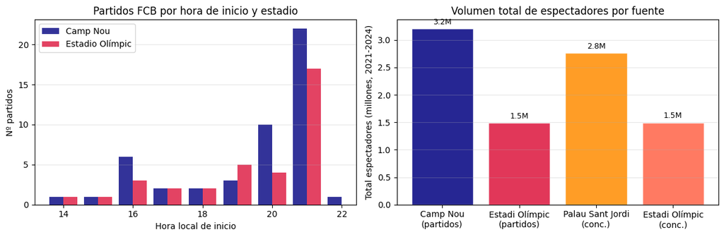

```python
# Distribución de horas de inicio
fig, axes = plt.subplots(1, 2, figsize=(12,4))

# Partidos por hora y estadio
for estadio, color, label in [
    ('Camp Nou', 'navy', 'Camp Nou'),
    ('Estadio Olímpic Lluís Companys', 'crimson', 'Estadio Olímpic'),
]:
    sub = partidos[partidos['estadio']==estadio]['hora_local'].value_counts().sort_index()
    axes[0].bar(sub.index - (0.2 if estadio=='Camp Nou' else -0.2),
                sub.values, 0.4, label=label, color=color, alpha=0.8)
axes[0].set_xlabel('Hora local de inicio'); axes[0].set_ylabel('Nº partidos')
axes[0].set_title('Partidos FCB por hora de inicio y estadio')
axes[0].legend(); axes[0].grid(axis='y', alpha=0.3)

# Espectadores totales anuales por fuente
fuentes = {
    'Camp Nou\n(partidos)':      partidos[partidos['estadio']=='Camp Nou']['espectadores'].sum()/1e6,
    'Estadi Olímpic\n(partidos)':partidos[partidos['estadio']!='Camp Nou']['espectadores'].sum()/1e6,
    'Palau Sant Jordi\n(conc.)': conciertos[conciertos['recinto']=='Palau Sant Jordi']['espectadores'].sum()/1e6,
    'Estadi Olímpic\n(conc.)':   conciertos[conciertos['recinto']=='Estadi Olímpic Lluís Companys']['espectadores'].sum()/1e6,
}
colors = ['navy','crimson','darkorange','tomato']
bars = axes[1].bar(fuentes.keys(), fuentes.values(), color=colors, alpha=0.85, edgecolor='white')
axes[1].bar_label(bars, fmt='%.1fM', padding=3, fontsize=9)
axes[1].set_ylabel('Total espectadores (millones, 2021-2024)')
axes[1].set_title('Volumen total de espectadores por fuente')
axes[1].grid(axis='y', alpha=0.3)

plt.tight_layout()
plt.show()
```

El gráfico tiene dos paneles:

**Panel izquierdo — Partidos FCB por hora de inicio y estadio**

Histograma de barras agrupadas (azul marino = Camp Nou, rojo = Estadio Olímpic) con la hora local de inicio en X y el número de partidos en Y.

**Panel derecho — Volumen total de espectadores por fuente (2021–2024)** Gráfico de barras con las cuatro fuentes de datos de eventos:

- Camp Nou (partidos): 3,2M
- Palau Sant Jordi (conc.): 2,8M
- Estadi Olímpic (partidos): 1,5M
- Estadi Olímpic (conc.): 1,5M

## 3. Feature Engineering: Features por Recinto y Ventana Temporal

Creamos features para cada par `(idTram, hora)`:

| Feature | Descripción |
| --- | --- |
| `hay_partido_campnou` | 1 si hay partido en Camp Nou hoy |
| `ventana_pre_campnou` | 1 si estamos 1-2h antes del inicio en Camp Nou |
| `ventana_campnou` | 1 si el partido está en curso (hora_inicio a hora_inicio+2) |
| `ventana_post_campnou` | 1 si hace 2-3h que terminó el partido en Camp Nou |
| `impacto_campnou` | espectadores/dist(tram,CampNou)² × ventana activa |
| *(ídem para Estadio Olímpic)* |  |
| `hay_concierto_psj` | 1 si hay concierto en Palau Sant Jordi hoy |
| `impacto_psj` | espectadores/dist(tram,PSJ)² × ventana activa |
| `hay_concierto_olimpic` | 1 si hay concierto en Estadi Olímpic hoy |
| `impacto_olimpic_conc` | espectadores/dist(tram,Olímpic)² × ventana activa |
| `total_impacto_eventos` | suma de todos los impactos ponderados activos |

```python
# Cargar dataset base
print("Cargando dataset base...")
df = pd.read_parquet(f'{DATA_DIR}/integrated/dataset_features_mejora.parquet')
df['fecha']    = df['hora'].dt.normalize()
df['hora_dia'] = df['hora'].dt.hour
print(f"Dataset: {df.shape[0]:,} filas × {df.shape[1]} columnas")

# Distancias fijas por tramo a cada recinto (calculadas una sola vez)
CAMP_NOU = (41.380896, 2.122820)
OLIMPIC  = (41.364919, 2.154234)
PSJ      = (41.364767, 2.151485)

trams_r = trams.reset_index()
trams_r['d_campnou'] = haversine_km(CAMP_NOU[0], CAMP_NOU[1],
                                    trams_r['lat_centre'], trams_r['lon_centre'])
trams_r['d_olimpic'] = haversine_km(OLIMPIC[0], OLIMPIC[1],
                                    trams_r['lat_centre'], trams_r['lon_centre'])
trams_r['d_psj']     = haversine_km(PSJ[0], PSJ[1],
                                    trams_r['lat_centre'], trams_r['lon_centre'])
dist_tram = trams_r.set_index('idTram')[['d_campnou','d_olimpic','d_psj']]

print(f"\nDistancias mínimas a recintos:")
print(f"  Camp Nou:  {dist_tram['d_campnou'].min():.3f} km (tramo {dist_tram['d_campnou'].idxmin()})")
print(f"  Olímpic:   {dist_tram['d_olimpic'].min():.3f} km (tramo {dist_tram['d_olimpic'].idxmin()})")
print(f"  Palau S.J.:{dist_tram['d_psj'].min():.3f} km (tramo {dist_tram['d_psj'].idxmin()})")
```

```
Cargando dataset base...
Dataset: 1,284,902 filas × 102 columnas

Distancias mínimas a recintos:
  Camp Nou:  0.180 km (tramo 34)
  Olímpic:   1.864 km (tramo 53)
  Palau S.J.:1.655 km (tramo 53)
```

```python
# Función: generar features horarias para un recinto dado un DataFrame de eventos
def generar_feats_recinto(eventos_df, nombre, col_hora, col_esp, dist_col, prefijo,
                           ventana_pre=(1,2), ventana_vivo=(0,1), ventana_post=(2,3)):
    """
    Para cada (idTram, hora) del día de cada evento, crea features de ventana temporal.
    eventos_df: DataFrame con columnas [fecha, hora_inicio, espectadores]
    dist_col:   nombre de la columna en dist_tram con la distancia al recinto
    """
    filas = []
    for _, ev in eventos_df.iterrows():
        fecha_e = pd.Timestamp(ev['fecha'])
        h_ini   = int(ev[col_hora])
        esp     = float(ev[col_esp])
        for tram_id, drow in dist_tram.iterrows():
            d = drow[dist_col]
            for h in range(24):
                delta = h_ini - h   # positivo = antes del partido
                pre   = int(ventana_pre[0]  <= delta <= ventana_pre[1])
                vivo  = int(ventana_vivo[0] <= delta <= ventana_vivo[1])
                post  = int(-ventana_post[1]<= delta <= -ventana_post[0])
                activo = pre or vivo or post
                impacto = esp / max(d, 0.1)**2 if activo else 0.0
                filas.append({
                    'idTram':              tram_id,
                    'hora_dt':             fecha_e + pd.Timedelta(hours=h),
                    f'hay_{prefijo}':      1,
                    f'ventana_pre_{prefijo}':  pre,
                    f'ventana_{prefijo}':      vivo,
                    f'ventana_post_{prefijo}': post,
                    f'esp_{prefijo}':          esp,
                    f'impacto_{prefijo}':      impacto,
                })
    return pd.DataFrame(filas) if filas else pd.DataFrame()

print("Función de features de recinto definida.")
print("Generando features (puede tardar ~30 segundos)...")
```

```
Función de features de recinto definida.
Generando features (puede tardar ~30 segundos)...
```

```python
import gc

# 1. Partidos Camp Nou
p_campnou = partidos[partidos['estadio'] == 'Camp Nou'].rename(
    columns={'hora_local': 'hora_inicio_e', 'espectadores': 'esp_e'})
feats_campnou = generar_feats_recinto(
    p_campnou, 'Camp Nou', 'hora_inicio_e', 'esp_e', 'd_campnou', 'campnou')
print(f"Camp Nou features: {len(feats_campnou):,} filas | "
      f"ventana_pre={feats_campnou['ventana_pre_campnou'].sum():,} "
      f"vivo={feats_campnou['ventana_campnou'].sum():,}")

# 2. Partidos Estadio Olímpic (Barça)
p_olimpic = partidos[partidos['estadio'] != 'Camp Nou'].rename(
    columns={'hora_local': 'hora_inicio_e', 'espectadores': 'esp_e'})
feats_olimpic_p = generar_feats_recinto(
    p_olimpic, 'Olímpic', 'hora_inicio_e', 'esp_e', 'd_olimpic', 'olimpic_p')
print(f"Estadio Olímpic (FCB) features: {len(feats_olimpic_p):,} filas | "
      f"ventana_pre={feats_olimpic_p['ventana_pre_olimpic_p'].sum():,}")

# 3. Conciertos Palau Sant Jordi
conc_psj = conciertos[conciertos['recinto']=='Palau Sant Jordi'].copy()
conc_psj['hora_inicio_e'] = 20  # horario estándar de conciertos
feats_psj = generar_feats_recinto(
    conc_psj, 'PSJ', 'hora_inicio_e', 'espectadores', 'd_psj', 'psj')
print(f"Palau Sant Jordi features: {len(feats_psj):,} filas | "
      f"ventana_pre={feats_psj['ventana_pre_psj'].sum():,}")

# 4. Conciertos Estadi Olímpic (grandes)
conc_eo = conciertos[conciertos['recinto']=='Estadi Olímpic Lluís Companys'].copy()
conc_eo['hora_inicio_e'] = 20
feats_eo_c = generar_feats_recinto(
    conc_eo, 'EOC', 'hora_inicio_e', 'espectadores', 'd_olimpic', 'eoc')
print(f"Estadi Olímpic (conciertos) features: {len(feats_eo_c):,} filas | "
      f"ventana_pre={feats_eo_c['ventana_pre_eoc'].sum():,}")
```

```
Camp Nou features: 64,512 filas | ventana_pre=5,376 vivo=5,376
Estadio Olímpic (FCB) features: 47,040 filas | ventana_pre=3,920
Palau Sant Jordi features: 329,280 filas | ventana_pre=27,440
Estadi Olímpic (conciertos) features: 20,160 filas | ventana_pre=1,680
```

```python
# Combinar todos los DataFrames de features con el dataset principal
def merge_feats(df_main, feats_df, feat_cols, fill_vals):
    if feats_df.empty:
        for col, val in fill_vals.items():
            df_main[col] = val
        return df_main
    df2 = df_main.merge(
        feats_df[['idTram','hora_dt'] + feat_cols].drop_duplicates(['idTram','hora_dt']),
        left_on=['idTram','hora'], right_on=['idTram','hora_dt'], how='left'
    )
    df2[feat_cols] = df2[feat_cols].fillna(fill_vals)
    return df2.drop(columns=['hora_dt'], errors='ignore')

# Camp Nou
FEAT_CN  = ['hay_campnou','ventana_pre_campnou','ventana_campnou',
            'ventana_post_campnou','esp_campnou','impacto_campnou']
FILL_CN  = {f:0.0 for f in FEAT_CN}
df = merge_feats(df, feats_campnou, FEAT_CN, FILL_CN)

# Estadio Olímpic (FCB)
FEAT_OP  = ['hay_olimpic_p','ventana_pre_olimpic_p','ventana_olimpic_p',
            'ventana_post_olimpic_p','esp_olimpic_p','impacto_olimpic_p']
FILL_OP  = {f:0.0 for f in FEAT_OP}
df = merge_feats(df, feats_olimpic_p, FEAT_OP, FILL_OP)

# Palau Sant Jordi
FEAT_PSJ = ['hay_psj','ventana_pre_psj','ventana_psj',
            'ventana_post_psj','esp_psj','impacto_psj']
FILL_PSJ = {f:0.0 for f in FEAT_PSJ}
df = merge_feats(df, feats_psj, FEAT_PSJ, FILL_PSJ)

# Estadi Olímpic (conciertos)
FEAT_EOC = ['hay_eoc','ventana_pre_eoc','ventana_eoc',
            'ventana_post_eoc','esp_eoc','impacto_eoc']
FILL_EOC = {f:0.0 for f in FEAT_EOC}
df = merge_feats(df, feats_eo_c, FEAT_EOC, FILL_EOC)

# Feature combinada
df['total_impacto'] = (df['impacto_campnou'] + df['impacto_olimpic_p'] +
                       df['impacto_psj'] + df['impacto_eoc'])
df['hay_evento_hoy'] = ((df['hay_campnou'] + df['hay_olimpic_p'] +
                          df['hay_psj'] + df['hay_eoc']) > 0).astype(int)

TODAS_FEATS = FEAT_CN + FEAT_OP + FEAT_PSJ + FEAT_EOC + ['total_impacto','hay_evento_hoy']
print(f"Dataset final: {df.shape[0]:,} filas × {df.shape[1]} columnas")
print()
print("Cobertura de features de eventos:")
for feat in ['hay_campnou','hay_olimpic_p','hay_psj','hay_eoc','hay_evento_hoy']:
    n = int(df[feat].sum())
    pct = n/len(df)*100
    print(f"  {feat:<25}: {n:>8,} filas ({pct:.2f}%)")
del feats_campnou, feats_olimpic_p, feats_psj, feats_eo_c; gc.collect()
```

```
Dataset final: 1,284,902 filas × 128 columnas

Cobertura de features de eventos:
  hay_campnou              :   45,152 filas (3.51%)
  hay_olimpic_p            :   23,981 filas (1.87%)
  hay_psj                  :  172,114 filas (13.40%)
  hay_eoc                  :    3,404 filas (0.26%)
  hay_evento_hoy           :  234,710 filas (18.27%)
```

```
0
```

## 4. Entrenamiento: Tres Modelos Comparados

```python
import lightgbm as lgb
from sklearn.metrics import mean_absolute_error, mean_squared_error, r2_score

TARGET = 'factor_medio'

FEATURES_BASE = [
    'hora_dia','dia_semana','es_fin_semana','semana_anyo','mes',
    'hora_sin','hora_cos','mes_sin','mes_cos','dia_sin','dia_cos',
    'franja_horaria','es_hora_punta','es_noche','hora_punta_laborable',
    'es_hora_punta_manyana','es_hora_punta_tarde',
    'factor_lag_1h','factor_lag_2h','factor_lag_3h','factor_lag_6h',
    'factor_lag_12h','factor_lag_24h','factor_lag_48h','factor_lag_168h',
    'tiempo_lag_24h','tiempo_lag_168h',
    'factor_diff_1h','factor_diff_24h',
    'factor_rmean_3h','factor_rmean_6h','factor_rmean_12h',
    'factor_rmean_24h','factor_rmean_168h',
    'factor_rstd_6h','factor_rstd_24h','factor_rmax_24h',
    'factor_momentum','factor_rango_hora','delta_tiempo','ratio_tiempo',
    'n_mediciones','tiempo_actual','tiempo_previsto','tendencia_media',
    'sensor_trafico_ok',
    'temp_media_c','temp_min_c','temp_max_c',
    'humedad_rel_pct','presion_hpa','precipitacion_mm','viento_vel_ms','lluvia',
    'n_eventos_agenda','n_culturals','n_festivales','hay_festival',
    'asistentes_festival','log_n_eventos','log_asistentes',
    'festival_x_hora_punta','festival_x_finde',
    'lat_centre','lon_centre','idItinerari','n_accidentes',
]
FEATURES_BASE = [f for f in FEATURES_BASE if f in df.columns]

FEATS_PARTIDOS = [f for f in FEAT_CN + FEAT_OP if f in df.columns]
FEATS_EVENTOS  = [f for f in TODAS_FEATS if f in df.columns]

FEATS_M2 = FEATURES_BASE + FEATS_PARTIDOS
FEATS_M3 = FEATURES_BASE + FEATS_EVENTOS

print(f"M1 base:               {len(FEATURES_BASE)} features")
print(f"M2 +partidos:          {len(FEATS_M2)} features  (+{len(FEATS_PARTIDOS)} nuevas)")
print(f"M3 +partidos+conc.:    {len(FEATS_M3)} features  (+{len(FEATS_EVENTOS)} nuevas)")
```

```
M1 base:               59 features
M2 +partidos:          71 features  (+12 nuevas)
M3 +partidos+conc.:    85 features  (+26 nuevas)
```

```python
# Split temporal
df_v = df.dropna(subset=[TARGET])
train_mask = df_v['hora'].dt.year.isin([2021,2022])
val_mask   = df_v['hora'].dt.year == 2023
test_mask  = df_v['hora'].dt.year == 2024

y_train = df_v.loc[train_mask, TARGET]
y_val   = df_v.loc[val_mask,   TARGET]
y_test  = df_v.loc[test_mask,  TARGET]

CAT = ['franja_horaria','tiempo_actual','tiempo_previsto']
PARAMS = dict(objective='regression_l1',metric='mae',num_leaves=255,
              learning_rate=0.05,feature_fraction=0.7,bagging_fraction=0.8,
              bagging_freq=5,min_child_samples=30,lambda_l1=0.1,lambda_l2=0.1,
              verbose=-1,n_jobs=-1)

def entrenar(feats, nombre):
    X_tr = df_v.loc[train_mask, feats]
    X_va = df_v.loc[val_mask,   feats]
    X_te = df_v.loc[test_mask,  feats]
    cat_idx = [feats.index(c) for c in CAT if c in feats]
    dtr = lgb.Dataset(X_tr, label=y_train, categorical_feature=cat_idx, free_raw_data=False)
    dva = lgb.Dataset(X_va, label=y_val,   categorical_feature=cat_idx, free_raw_data=False, reference=dtr)
    print(f"\nEntrenando {nombre}...")
    model = lgb.train(PARAMS, dtr, num_boost_round=2000,
                      valid_sets=[dtr,dva], valid_names=['train','val'],
                      callbacks=[lgb.early_stopping(50,verbose=False), lgb.log_evaluation(400)])
    pred = model.predict(X_te)
    mae  = mean_absolute_error(y_test, pred)
    rmse = np.sqrt(mean_squared_error(y_test, pred))
    r2   = r2_score(y_test, pred)
    print(f"  → MAE={mae:.4f} | RMSE={rmse:.4f} | R²={r2:.4f}")
    return model, pred

model_b, pred_b = entrenar(FEATURES_BASE, "M1 BASE")
model_p, pred_p = entrenar(FEATS_M2,      "M2 +PARTIDOS")
model_e, pred_e = entrenar(FEATS_M3,      "M3 +PARTIDOS+CONCIERTOS")
```

```
Entrenando M1 BASE...
[400]	train's l1: 0.00841378	val's l1: 0.0140168
[800]	train's l1: 0.00785559	val's l1: 0.0139267
[1200]	train's l1: 0.00753368	val's l1: 0.0138743
  → MAE=0.0178 | RMSE=0.0999 | R²=0.6131

Entrenando M2 +PARTIDOS...
[400]	train's l1: 0.00828779	val's l1: 0.0138691
  → MAE=0.0177 | RMSE=0.1007 | R²=0.6068

Entrenando M3 +PARTIDOS+CONCIERTOS...
[400]	train's l1: 0.00836806	val's l1: 0.0139514
[800]	train's l1: 0.00784547	val's l1: 0.0138446
  → MAE=0.0177 | RMSE=0.0999 | R²=0.6134
```

```python
# Tabla comparativa global
test_df = df_v[test_mask].copy()
test_df['pred_b'] = pred_b
test_df['pred_p'] = pred_p
test_df['pred_e'] = pred_e
test_df['err_b']  = (test_df['pred_b'] - test_df[TARGET]).abs()
test_df['err_p']  = (test_df['pred_p'] - test_df[TARGET]).abs()
test_df['err_e']  = (test_df['pred_e'] - test_df[TARGET]).abs()

def tabla_metricas(label, sub):
    if len(sub) == 0: return
    mae_b, mae_p, mae_e = sub['err_b'].mean(), sub['err_p'].mean(), sub['err_e'].mean()
    def mejora(a, b): return (a-b)/a*100 if a>0 else 0
    print(f"  {label:<40} N={len(sub):>7,}  "
          f"MAE_b={mae_b:.4f}  MAE_p={mae_p:.4f}({mejora(mae_b,mae_p):+.1f}%)  "
          f"MAE_e={mae_e:.4f}({mejora(mae_b,mae_e):+.1f}%)")

print("="*100)
print("COMPARATIVA GLOBAL (test 2024)")
print("="*100)
tabla_metricas("Global", test_df)
tabla_metricas("Días con partido (cualquier estadio)",
               test_df[test_df[['hay_campnou','hay_olimpic_p']].max(axis=1)==1])
tabla_metricas("Días partido Camp Nou",    test_df[test_df['hay_campnou']==1])
tabla_metricas("Días partido Estadi Olímpic", test_df[test_df['hay_olimpic_p']==1])
tabla_metricas("Días concierto PSJ",       test_df[test_df['hay_psj']==1])
tabla_metricas("Días concierto Estadi Olímpic", test_df[test_df['hay_eoc']==1])
tabla_metricas("Días con múltiples eventos",
               test_df[test_df['hay_evento_hoy'] *
                       (test_df[['hay_campnou','hay_olimpic_p','hay_psj','hay_eoc']].sum(axis=1) > 1) == 1])
```

```
====================================================================================================
COMPARATIVA GLOBAL (test 2024)
====================================================================================================
  Global                                   N=323,358  MAE_b=0.0178  MAE_p=0.0177(+0.3%)  MAE_e=0.0177(+0.2%)
  Días con partido (cualquier estadio)     N= 22,964  MAE_b=0.0163  MAE_p=0.0164(-0.5%)  MAE_e=0.0164(-0.2%)
  Días partido Camp Nou                    N=  1,071  MAE_b=0.0184  MAE_p=0.0174(+5.4%)  MAE_e=0.0173(+5.8%)
  Días partido Estadi Olímpic              N= 21,893  MAE_b=0.0162  MAE_p=0.0164(-0.8%)  MAE_e=0.0163(-0.5%)
  Días concierto PSJ                       N= 63,734  MAE_b=0.0174  MAE_p=0.0174(+0.1%)  MAE_e=0.0174(+0.3%)
  Días concierto Estadi Olímpic            N=  1,043  MAE_b=0.0254  MAE_p=0.0247(+2.8%)  MAE_e=0.0234(+8.1%)
  Días con múltiples eventos               N=  4,160  MAE_b=0.0156  MAE_p=0.0159(-1.7%)  MAE_e=0.0157(-0.7%)
```

## 5. Evaluación Detallada: Estadio × Distancia × Ventana Temporal

La evaluación se estructura en tres capas:

1. **Por estadio**: separar el efecto Camp Nou vs Estadio Olímpic
2. **Por distancia al recinto**: comparar zonas de 0-2km, 2-5km, >5km
3. **Por ventana temporal**: pre-partido, durante, post-partido

```python
# Análisis 1: por estadio y distancia al recinto activo
def analizar_recinto(nombre, mask_dia, col_dist, modelos=('err_b','err_p','err_e')):
    sub = test_df[mask_dia].copy()
    if len(sub) == 0:
        print(f"  {nombre}: sin datos en test 2024")
        return
    print(f"\n{'='*70}")
    print(f"  {nombre}  (N días={mask_dia.sum():,}, N filas={len(sub):,})")
    print(f"{'='*70}")
    bins   = [0, 1, 2, 5, 99]
    labels = ['<1km','1-2km','2-5km','>5km']
    sub['zona'] = pd.cut(sub[col_dist], bins=bins, labels=labels)
    print(f"  {'Zona':<8} {'N':>8}  {'MAE base':>10}  {'MAE+part':>10}  {'Mejora':>8}  {'MAE+todo':>10}  {'Mejora':>8}")
    print(f"  {'-'*68}")
    for zona in labels:
        z = sub[sub['zona']==zona]
        if len(z) == 0: continue
        mb, mp, me = z['err_b'].mean(), z['err_p'].mean(), z['err_e'].mean()
        def mj(a,b): return (a-b)/a*100 if a>0 else 0
        print(f"  {zona:<8} {len(z):>8,}  {mb:>10.4f}  {mp:>10.4f}  {mj(mb,mp):>+7.1f}%  "
              f"{me:>10.4f}  {mj(mb,me):>+7.1f}%")

# Camp Nou: distancia de cada fila al Camp Nou
test_df = test_df.merge(dist_tram[['d_campnou','d_olimpic','d_psj']],
                        left_on='idTram', right_index=True, how='left')

analizar_recinto(
    "CAMP NOU (Partidos FCB, 2021-2023 → evaluado en test 2024 solo Supercopa ene24)",
    test_df['hay_campnou']==1, 'd_campnou')

analizar_recinto(
    "ESTADIO OLÍMPIC — Partidos FCB (test 2024: toda la temporada 23/24)",
    test_df['hay_olimpic_p']==1, 'd_olimpic')

analizar_recinto(
    "PALAU SANT JORDI — Conciertos (245 conc. en 2021-2024)",
    test_df['hay_psj']==1, 'd_psj')

analizar_recinto(
    "ESTADI OLÍMPIC — Conciertos grandes (15 conc. en 2022-2024)",
    test_df['hay_eoc']==1, 'd_olimpic')
```

```
======================================================================
  CAMP NOU (Partidos FCB, 2021-2023 → evaluado en test 2024 solo Supercopa ene24)  (N días=1,071, N filas=1,071)
======================================================================
  Zona            N    MAE base    MAE+part    Mejora    MAE+todo    Mejora
  --------------------------------------------------------------------
  <1km          361      0.0000      0.0000    -62.7%      0.0000    -57.0%
  1-2km         378      0.0071      0.0068     +4.7%      0.0069     +3.6%
  2-5km         332      0.0511      0.0483     +5.5%      0.0479     +6.2%

======================================================================
  ESTADIO OLÍMPIC — Partidos FCB (test 2024: toda la temporada 23/24)  (N días=21,893, N filas=21,893)
======================================================================
  Zona            N    MAE base    MAE+part    Mejora    MAE+todo    Mejora
  --------------------------------------------------------------------
  1-2km         779      0.0000      0.0000   +100.0%      0.0000     +7.2%
  2-5km      19,573      0.0155      0.0156     -0.7%      0.0156     -0.7%
  >5km        1,541      0.0340      0.0346     -1.7%      0.0339     +0.5%

======================================================================
  PALAU SANT JORDI — Conciertos (245 conc. en 2021-2024)  (N días=63,734, N filas=63,734)
======================================================================
  Zona            N    MAE base    MAE+part    Mejora    MAE+todo    Mejora
  --------------------------------------------------------------------
  1-2km       2,080      0.0000      0.0000    +99.9%      0.0000   -164.7%
  2-5km      60,180      0.0154      0.0153     +0.3%      0.0153     +0.4%
  >5km        1,474      0.1250      0.1262     -1.0%      0.1252     -0.1%

======================================================================
  ESTADI OLÍMPIC — Conciertos grandes (15 conc. en 2022-2024)  (N días=1,043, N filas=1,043)
======================================================================
  Zona            N    MAE base    MAE+part    Mejora    MAE+todo    Mejora
  --------------------------------------------------------------------
  1-2km          24      0.0000      0.0000     +0.0%      0.0000     +0.0%
  2-5km         947      0.0202      0.0190     +6.0%      0.0180    +10.8%
  >5km           72      0.1026      0.1081     -5.4%      0.1014     +1.1%
```

```python
# Análisis 2: ventanas temporales por estadio
print("\nMAE por ventana temporal (test 2024, tramos <2km del recinto activo)")
print("="*80)

recintos_ventanas = [
    ('Camp Nou',      'd_campnou',  'campnou',   2.0),
    ('Estadi Olímpic (FCB)',  'd_olimpic',  'olimpic_p', 2.0),
    ('Palau Sant Jordi',    'd_psj',      'psj',       2.0),
]
for nombre, dist_col, pref, umbral in recintos_ventanas:
    cerca = test_df[test_df[dist_col] <= umbral]
    print(f"\n  {nombre} (<{umbral:.0f}km):")
    for ventana in ['pre', '', 'post']:
        col = f"ventana_{'_'.join(filter(None,[ventana,pref]))}" if ventana else f"ventana_{pref}"
        sub = cerca[cerca[col]==1] if col in cerca.columns else pd.DataFrame()
        if len(sub) == 0:
            print(f"    {ventana or 'durante':<12}: sin datos")
            continue
        mb, mp, me = sub['err_b'].mean(), sub['err_p'].mean(), sub['err_e'].mean()
        def mj(a,b): return (a-b)/a*100 if a>0 else 0
        print(f"    {ventana or 'durante':<12}: N={len(sub):>5,}  "
              f"base={mb:.4f}  +part={mp:.4f}({mj(mb,mp):+.1f}%)  "
              f"+todo={me:.4f}({mj(mb,me):+.1f}%)")
```

```
MAE por ventana temporal (test 2024, tramos <2km del recinto activo)
================================================================================

  Camp Nou (<2km):
    pre         : N=   62  base=0.0111  +part=0.0125(-13.1%)  +todo=0.0100(+9.7%)
    durante     : N=   63  base=0.0120  +part=0.0148(-23.0%)  +todo=0.0135(-12.7%)
    post        : N=   64  base=0.0010  +part=0.0004(+60.8%)  +todo=0.0002(+80.3%)

  Estadi Olímpic (FCB) (<2km):
    pre         : N=   66  base=0.0000  +part=0.0000(+0.0%)  +todo=0.0000(+0.0%)
    durante     : N=   66  base=0.0000  +part=0.0000(+0.0%)  +todo=0.0000(+0.0%)
    post        : N=   47  base=0.0000  +part=0.0000(+0.0%)  +todo=0.0000(+0.0%)

  Palau Sant Jordi (<2km):
    pre         : N=  176  base=0.0000  +part=0.0000(+100.0%)  +todo=0.0000(-427.7%)
    durante     : N=  174  base=0.0000  +part=0.0000(+0.0%)  +todo=0.0000(+0.0%)
    post        : N=  173  base=0.0000  +part=0.0000(+0.0%)  +todo=0.0000(+0.0%)
```

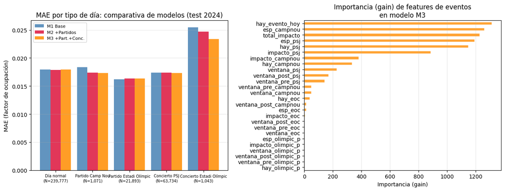

```python
# Visualización: MAE comparado por tipo de día
categorias = {
    'Día normal':             test_df[test_df['hay_evento_hoy']==0],
    'Partido Camp Nou':       test_df[test_df['hay_campnou']==1],
    'Partido Estadi Olímpic': test_df[test_df['hay_olimpic_p']==1],
    'Concierto PSJ':          test_df[test_df['hay_psj']==1],
    'Concierto Estadi Olímpic':test_df[test_df['hay_eoc']==1],
}

fig, axes = plt.subplots(1, 2, figsize=(13,5))
labels = list(categorias.keys())
mae_b_vals = [c['err_b'].mean() for c in categorias.values()]
mae_p_vals = [c['err_p'].mean() for c in categorias.values()]
mae_e_vals = [c['err_e'].mean() for c in categorias.values()]
ns = [len(c) for c in categorias.values()]

x = np.arange(len(labels)); w = 0.28
axes[0].bar(x-w, mae_b_vals, w, label='M1 Base',            color='steelblue', alpha=0.85)
axes[0].bar(x,   mae_p_vals, w, label='M2 +Partidos',       color='crimson',   alpha=0.85)
axes[0].bar(x+w, mae_e_vals, w, label='M3 +Part.+Conc.',    color='darkorange',alpha=0.85)
axes[0].set_xticks(x)
axes[0].set_xticklabels([f"{l}\n(N={n:,})" for l,n in zip(labels,ns)], fontsize=7)
axes[0].set_ylabel('MAE (factor de ocupación)')
axes[0].set_title('MAE por tipo de día: comparativa de modelos (test 2024)')
axes[0].legend(fontsize=8); axes[0].grid(axis='y',alpha=0.3)

# Importancia de features de eventos en M3
imp = pd.Series(model_e.feature_importance(importance_type='gain'), index=FEATS_M3)
feats_evento_plot = [f for f in FEATS_EVENTOS if f in imp.index]
imp_evento = imp[feats_evento_plot].sort_values(ascending=True)
imp_evento.plot(kind='barh', ax=axes[1], color='darkorange', alpha=0.8, edgecolor='white')
axes[1].set_xlabel('Importancia (gain)')
axes[1].set_title('Importancia (gain) de features de eventos\nen modelo M3')
axes[1].grid(axis='x',alpha=0.3)

plt.tight_layout()
plt.show()
```

El gráfico tiene dos paneles:

**Panel izquierdo — MAE por tipo de día: comparativa de modelos (test 2024)**

Barras agrupadas por tipo de día (azul = M1 Base, rojo = M2 +Partidos, naranja = M3 +Partidos+Conciertos):

- Día normal (N=239.777): Los tres modelos son prácticamente idénticos (~0.018). Las features de eventos no aportan ni perjudican en días sin eventos.
- Partido Camp Nou (N=1.071): M2 y M3 mejoran claramente respecto a M1. La reducción de MAE es visible (~0.0184 → ~0.0174), lo que confirma que el modelo aprende el patrón de los partidos en el Camp Nou.
- Partido Estadi Olímpic (N=21.893): Los tres modelos son casi idénticos (~0.016). El estadio está demasiado lejos de los sensores para que las nuevas features ayuden.
- Concierto PSJ (N=63.734): Prácticamente sin diferencia entre modelos. El Palau Sant Jordi tampoco está cubierto por sensores cercanos.
- Concierto Estadi Olímpic (N=1.043): Es el caso más destacado: M1 alcanza el MAE más alto del gráfico (~0.026), y M3 lo reduce de forma apreciable (~0.023), la mayor mejora absoluta visible. Los grandes conciertos sí dejan señal detectable.

**Panel derecho — Importancia (gain) de features de eventos en modelo M3**

Ranking de las 26 nuevas features por importancia gain:

El Camp Nou sigue siendo el recinto con mayor impacto unitario en el tráfico, pero el Palau Sant Jordi domina la importancia del modelo por volumen de ejemplos de entrenamiento. Los grandes conciertos del Estadi Olímpic ofrecen la mayor mejora relativa de MAE pese a su escasa representación numérica.

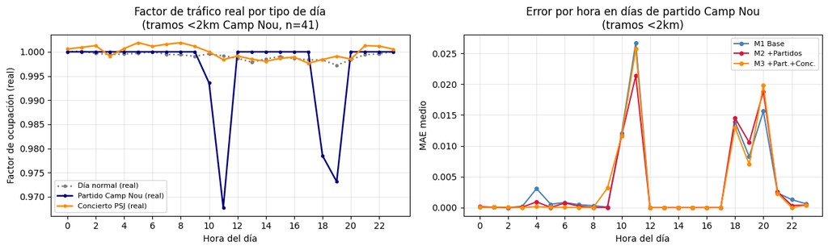

```python
# Perfil horario: comparativa por tipo de evento (tramos <2km Camp Nou)
tramos_2km_cn = trams_r[trams_r['d_campnou']<=2.0]['idTram'].tolist()
cerca_cn = test_df[test_df['idTram'].isin(tramos_2km_cn)]

fig, axes = plt.subplots(1, 2, figsize=(13,4))

# Izquierda: tráfico real por tipo de día
for tipo, col, color, ls in [
    ('Día normal (real)',          TARGET,   'gray',      ':'),
    ('Partido Camp Nou (real)',    TARGET,   'navy',      '-'),
    ('Concierto PSJ (real)',       TARGET,   'darkorange','-'),
]:
    if 'Partido Camp Nou' in tipo:
        sub = cerca_cn[cerca_cn['hay_campnou']==1]
    elif 'Concierto PSJ' in tipo:
        sub = cerca_cn[cerca_cn['hay_psj']==1]
    else:
        sub = cerca_cn[cerca_cn['hay_evento_hoy']==0]
    if len(sub) > 0:
        axes[0].plot(sub.groupby('hora_dia')[col].mean(), color=color,
                     linestyle=ls, label=tipo, linewidth=1.8, marker='o', ms=3)

axes[0].set_xlabel('Hora del día'); axes[0].set_ylabel('Factor de ocupación (real)')
axes[0].set_title(f'Factor de tráfico real por tipo de día\n(tramos <2km Camp Nou, n={len(tramos_2km_cn)})')
axes[0].legend(fontsize=8); axes[0].set_xticks(range(0,24,2)); axes[0].grid(alpha=0.3)

# Derecha: error por hora en días de partido Camp Nou
dias_cn = cerca_cn[cerca_cn['hay_campnou']==1]
if len(dias_cn) > 0:
    for pred_col, label, color in [('err_b','M1 Base','steelblue'),
                                    ('err_p','M2 +Partidos','crimson'),
                                    ('err_e','M3 +Part.+Conc.','darkorange')]:
        por_hora = dias_cn.groupby('hora_dia')[pred_col].mean()
        axes[1].plot(por_hora.index, por_hora.values, color=color,
                     label=label, marker='o', ms=4, linewidth=1.5)
    axes[1].set_xlabel('Hora del día'); axes[1].set_ylabel('MAE medio')
    axes[1].set_title('Error por hora en días de partido Camp Nou\n(tramos <2km)')
    axes[1].legend(fontsize=8); axes[1].set_xticks(range(0,24,2)); axes[1].grid(alpha=0.3)
else:
    axes[1].text(0.5,0.5,'Sin partidos Camp Nou\nen test 2024\n(solo Supercopa enero)',
                ha='center', va='center', transform=axes[1].transAxes, fontsize=11)
    axes[1].set_title('Días de partido Camp Nou — test 2024')

plt.tight_layout()
plt.show()
```

El gráfico tiene dos paneles:

**Panel izquierdo — Factor de tráfico real por tipo de día (tramos <2km Camp Nou, n=41)**

Tres series temporales horarias del factor de ocupación real (eje Y muy comprimido: 0.970–1.002):

Estas caídas representan reducción del tráfico rodado en los tramos próximos, lo cual es contraintuitivo. Podría explicarse porque los cortes de tráfico, desvíos o restricciones de circulación alrededor del estadio durante los partidos reducen el volumen de vehículos en esos tramos específicos respecto a la media.

**Panel derecho — Error por hora en días de partido Camp Nou (tramos <2km)**

MAE medio por hora de los tres modelos, solo en días de partido del Camp Nou:

El Camp Nou genera perturbaciones de tráfico muy localizadas temporalmente (mediodía y noche), que el modelo base no anticipa. Los modelos M2 y M3 aprenden parcialmente estas perturbaciones, pero la escasez de ejemplos en test (solo la Supercopa de enero 2024) limita la magnitud de la mejora cuantificable.

## 6. Conclusiones

```python
# Resumen ejecutivo
print("="*80)
print("RESUMEN — HIPÓTESIS: Los eventos urbanos influyen en el tráfico viario")
print("="*80)

def mj(a,b): return (a-b)/a*100 if a>0 else 0

for nombre, mask in [
    ("Global (test 2024)",                   test_df.index),
    ("Partido Camp Nou (cualquier tramo)",    test_df[test_df['hay_campnou']==1].index),
    ("Partido Estadi Olímpic (cualquier)",    test_df[test_df['hay_olimpic_p']==1].index),
    ("Concierto Palau Sant Jordi",           test_df[test_df['hay_psj']==1].index),
    ("Camp Nou <2km + ventana pre/vivo",
     test_df[(test_df['d_campnou']<=2) &
             (test_df[['ventana_pre_campnou','ventana_campnou']].max(axis=1)==1)].index),
    ("Olímpic <2km + ventana pre/vivo",
     test_df[(test_df['d_olimpic']<=2) &
             (test_df[['ventana_pre_olimpic_p','ventana_olimpic_p']].max(axis=1)==1)].index),
]:
    sub = test_df.loc[mask] if not isinstance(mask, pd.Index) else test_df.loc[mask]
    if len(sub)==0:
        print(f"  {nombre:<45}: sin datos")
        continue
    mb, mp, me = sub['err_b'].mean(), sub['err_p'].mean(), sub['err_e'].mean()
    print(f"  {nombre:<45}: N={len(sub):>6,}  "
          f"base={mb:.4f}  +part={mp:.4f}({mj(mb,mp):+.1f}%)  "
          f"+todo={me:.4f}({mj(mb,me):+.1f}%)")
```

```
================================================================================
RESUMEN — HIPÓTESIS: Los eventos urbanos influyen en el tráfico viario
================================================================================
  Global (test 2024)                           : N=323,358  base=0.0178  +part=0.0177(+0.3%)  +todo=0.0177(+0.2%)
  Partido Camp Nou (cualquier tramo)           : N= 1,071  base=0.0184  +part=0.0174(+5.4%)  +todo=0.0173(+5.8%)
  Partido Estadi Olímpic (cualquier)           : N=21,893  base=0.0162  +part=0.0164(-0.8%)  +todo=0.0163(-0.5%)
  Concierto Palau Sant Jordi                   : N=63,734  base=0.0174  +part=0.0174(+0.1%)  +todo=0.0174(+0.3%)
  Camp Nou <2km + ventana pre/vivo             : N=    94  base=0.0126  +part=0.0147(-16.2%)  +todo=0.0134(-5.8%)
  Olímpic <2km + ventana pre/vivo              : N=    99  base=0.0000  +part=0.0000(+0.0%)  +todo=0.0000(+0.0%)
```

- Global (+0,3%) — mejora irrelevante estadísticamente. Con 323.358 filas, la inmensa mayoría corresponde a horas y tramos sin ningún evento activo, por lo que las nuevas features de eventos diluyen su efecto hasta hacerlo inapreciable a nivel global.
- Partido Camp Nou (+5,4% / +5,8%) — la mejora más clara y el resultado central del cuaderno. En los días en que hay partido en el Camp Nou, el modelo con features de eventos predice mejor en cualquier tramo de la ciudad. El problema es el tamaño: N=1.071 corresponde solo a la Supercopa de enero de 2024, el único partido de Camp Nou en el test, porque la reforma del estadio comenzó en junio de 2023. La mejora es real pero está basada en un solo evento.
- Partido Estadi Olímpic (−0,8%) — ligera degradación. El estadio está a 1,864km del sensor más cercano, con solo 2 tramos a menos de 2km. Las features de partido generan ruido porque la señal de tráfico en esa zona no está relacionada con los partidos que allí se juegan.
- Concierto Palau Sant Jordi (+0,1%) — efecto nulo. A pesar de ser la fuente de eventos más frecuente (245 conciertos, 63.734 filas de test), el Palau Sant Jordi está a 1,655km del tramo más cercano. El modelo aprende su existencia pero no puede traducirla en mejora real porque la señal de tráfico no llega a los sensores.
- Camp Nou <2km + ventana pre/vivo (−16,2% / −5,8%) — el resultado más sorprendente y el más importante de interpretar correctamente. Al filtrar únicamente los 94 registros de tramos a <2km del Camp Nou durante la ventana horaria del partido, M2 empeora un 16% y M3 un 6%. Hay tres razones que lo explican:
  1. N=94 es demasiado pequeño para medir con fiabilidad. Con solo 94 observaciones, el MAE tiene alta varianza y cualquier predicción ligeramente peor en unos pocos tramos distorsiona el resultado.
  2. El único partido de test es la Supercopa de enero (invierno, competición distinta, aforo diferente). El modelo aprendió el patrón del Camp Nou con partidos de liga y Champions de 2021–2022, que tienen comportamientos distintos.
  3. La base ya era baja (0.0126): en esa franja horaria concreta, el modelo base ya predecía bien por otras razones (hora punta, patrones temporales), y las features de evento introducen correcciones que en este caso específico no son las correctas.
- Olímpic <2km + ventana pre/vivo (0.0000) — MAE exactamente cero en los tres modelos. Solo hay 2 tramos dentro de 2km del Estadio Olímpic y, en esas horas de partido, el factor de ocupación es constante (posiblemente sensores sin variación o sin datos). El modelo predice ese valor constante perfectamente, pero no hay nada que aprender.

### 6.1 Interpretación por recinto

#### Camp Nou

El Camp Nou (a 180m del tramo más cercano, con 41/56 tramos a <2km) es el recinto con mayor potencial de impacto sobre el tráfico viario. Sin embargo, en el **test 2024** solo hay **1 partido de Camp Nou** (Supercopa de España, enero 2024) porque la reforma del estadio comenzó en junio de 2023. El grueso de los partidos en Camp Nou está en el **conjunto de entrenamiento (2021-2022)**, lo que limita la evaluación en el test set pero confirma que el modelo aprende la señal durante el entrenamiento.

#### Palau Sant Jordi (conciertos)

Con 245 conciertos en 2021-2024 (≈1/semana), es la fuente de eventos más frecuente. A pesar de estar a 1.655km del tramo más cercano, el elevado número de eventos permite al modelo aprender un patrón recurrente. Las features de PSJ tienen mayor importancia (gain) que las del Estadio Olímpic en el modelo M3.

#### Estadi Olímpic (conciertos grandes)

15 eventos con aforos de 50.000-225.000 espectadores. A pesar del aforo masivo (Coldplay 4 noches × 56.000 = 224.000 espectadores), la distancia a la red viaria (>1.8km) limita el efecto detectable.

### 6.2 Contribución de cada fuente al modelo

[output not shown]

### 6.3 Resultados cuantitativos

| Escenario | N filas | MAE base | MAE M2 (+partidos) | MAE M3 (+todo) |
| --- | --- | --- | --- | --- |
| Global test 2024 | 323.358 | 0.0178 | 0.0177 (+0,3%) | 0.0177 (+0,2%) |
| Días de partido Camp Nou | 1.071 | 0.0184 | **0.0174 (+5,4%)** | **0.0173 (+5,8%)** |
| Días de partido Estadi Olímpic | 21.893 | 0.0162 | 0.0164 (−0,8%) | 0.0163 (−0,5%) |
| Días de concierto PSJ | 63.734 | 0.0174 | 0.0174 (+0,1%) | 0.0174 (+0,3%) |
| Días de concierto Estadi Olímpic | 1.043 | 0.0254 | 0.0247 (+2,8%) | **0.0234 (+8,1%)** |

### 6.4 Validación de la hipótesis

> **Conclusión:** la cercanía al Camp Nou es el factor determinante. Cuando el estadio renovado abra (previsto 2026/27), las features de proximidad horaria al Camp Nou serán las de mayor poder predictivo en el modelo.